# Demonstration of model performance on a quadratic function

Zakhodyakin Gleb

08 10 2019

```r
library(mlr) # Machine Learning framework for R
library(stringr) # string processing
library(parallelMap) # Parallel computation
library(rpart.plot) # Visualization of rpart trees
library(tidyverse) # Data visualization and transformation
```

# Introduction

This notebook demonstrates how different models perform on a simple quadratic function.

Data is generated using the model:

$$y = (x - 10)^2 + N(0, 5)$$

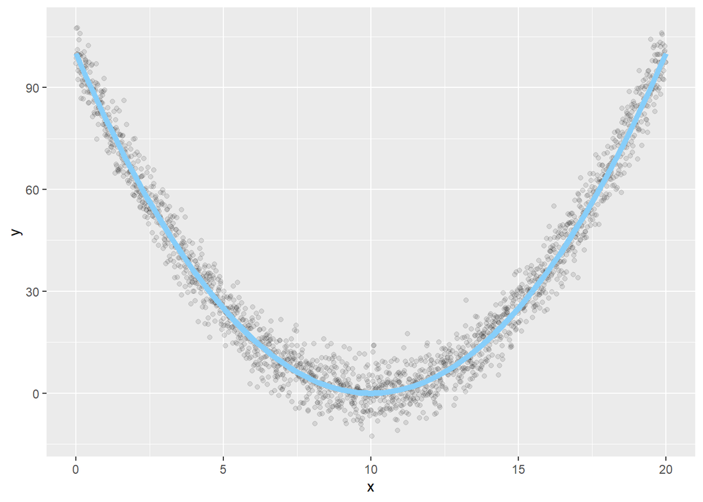

```r
set.seed(123)

true_f <- function(x) {
  (x - 10)^2
}

quadratic <-
  tibble(
    x = seq(0, 20, by = 0.01)
  ) %>%
  mutate(
    y =  true_f(x)+ rnorm(2001, sd = 5)
  )

ggplot(quadratic, aes(x, y)) +
  geom_point(alpha = 0.1) +
  stat_function(fun = true_f, color = 'lightSkyBlue', lwd = 2)
```

# Polynomial regression

Since we know that the functional form of the true $f(x)$ is polynomial, we can approximate it using the polynomial regression.

Here we create a learning task for MLR. Since the package can’t automatically include polynomial terms, we’ll add the $x^2$ term to the data table manually.

```r
tsk_quadratic_poly <- quadratic %>%
  mutate(x2 = x^2) %>%
  makeRegrTask(id = "Quadratic Function with Polynomial terms",
                              data = .,
                              target = "y")
```

Now we create a learner based on the multiple linear regression model:

```r
lrn_mlr <- makeLearner("regr.lm", id = "mlr")
```

To benchmark model performance, we need to define a list of metrics to calculate:

```r
# A list of model performance metrics for regression
ms_regr = list(mape, timetrain, mae, rmse, rsq)
```

and a resampling strategy, which will be 10 fold cross validation:

```r
rdesc_CV10 <- makeResampleDesc(method = "CV",
                                   iter = 10)
```

As a preparatory step, we detect the number of available CPU cores and define a helper function to print the benchmarking results in a table.

```r
# Detecting the number of avaliable CPU cores
num_cores <- parallel::detectCores()

# Function for printing benchmark results ordered by MAPE
printBenchmark <- function(benchmarkResults) {
  benchmarkResults %>%
  getBMRAggrPerformances(as.df = TRUE) %>%
  arrange(mape.test.mean) %>%
  dplyr::select(-task.id) %>%
  mutate_if(is.numeric, round, digits = 3)
}
```

Now we can benchmark our model’s performance.

```r
# Setting the random number generator for reproducibility
set.seed(123, "L'Ecuyer")

# Starting parallelization
parallelStartSocket(num_cores)
```

```
## Starting parallelization in mode=socket with cpus=16.
```

```r
bench_quadratic_mlr <-
  lrn_mlr %>%
  benchmark(learners = .,
            tasks = tsk_quadratic_poly,
            resampling = rdesc_CV10,
          measures = ms_regr,
         show.info = TRUE)
```

```
## Exporting objects to slaves for mode socket: .mlr.slave.options
```

```
## Mapping in parallel: mode = socket; level = mlr.benchmark; cpus = 16; elements = 1.
```

```r
parallelStop()
```

```
## Stopped parallelization. All cleaned up.
```

```r
bench_quadratic_mlr %>%
  printBenchmark()
```

```
##   learner.id mape.test.mean timetrain.test.mean mae.test.mean
## 1        mlr          0.883                   0         3.996
##   rmse.test.rmse rsq.test.mean
## 1          5.006         0.973
```

Let’s compare the predicted and the actual values using the polynomial regression model.

To simplify further comparisons, we’ll create a helper function that will do model training and plotting.

```r
try_model <- function(learner, task) {

  train(learner,task) %>% # training the specified learner
  predict(task) %>% # predicting
  as.data.frame() %>% # extracting results as a data frame
  cbind(getTaskData(task)) %>% # adding the data frame with predictors
  ggplot(aes(x)) +
  geom_point(aes(y = truth), alpha = 0.1) +
  stat_function(fun = true_f, color = 'lightSkyBlue', lwd = 2) +
  geom_line(aes(y = response), color = 'red') +
  labs(title = paste("Predictions from", getLearnerId(learner)),
       y = "response")

}
```

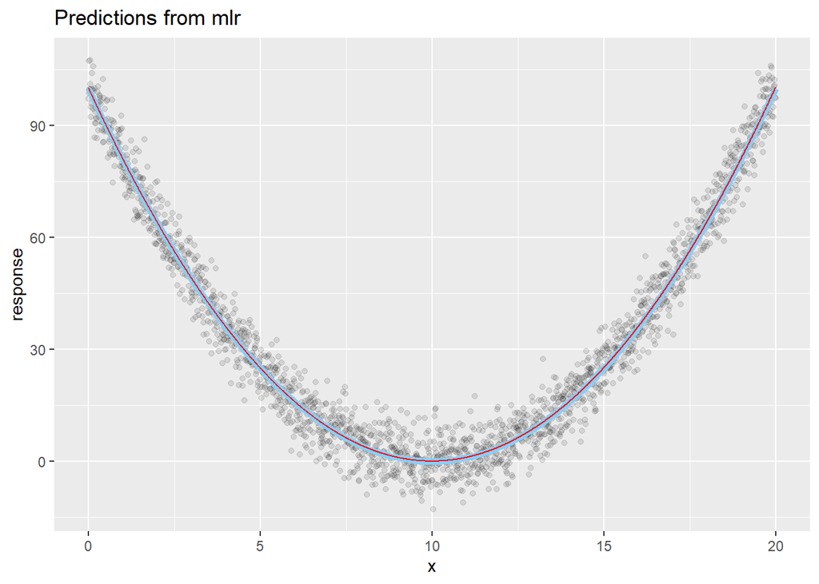

```r
try_model(lrn_mlr, tsk_quadratic_poly)
```

As we can see, the model is almost identical to the true $f(x)$.

# Tree - based models

In this section we consider two tree-based models - rpart and ctree. Both models will use the original data, without the added polynomial term.

## CART algorithm (rpart)

```r
tsk_quadratic <- makeRegrTask(id = "Quadratic Function",
                              data = quadratic,
                              target = "y")
```

Here we’ll compare the estimated $f(x)$ to the actual one visually.

First, let’s try the default values for the parameters.

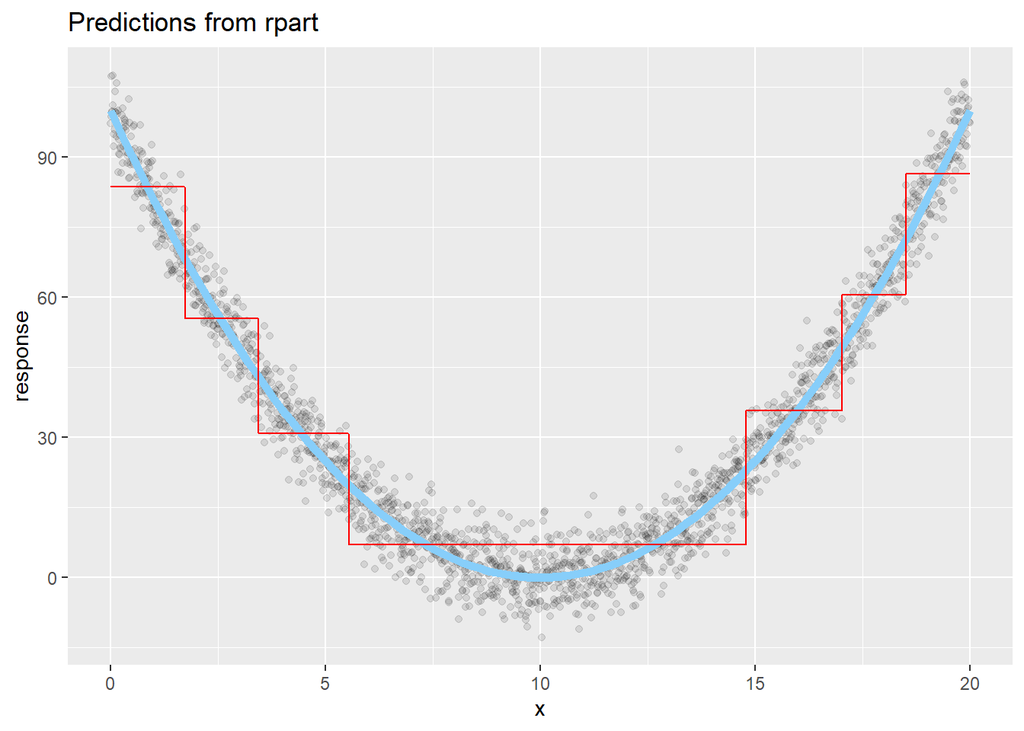

```r
makeLearner("regr.rpart", id = "rpart") %>%
  try_model(tsk_quadratic)
```

The algorithm has approximated the non-linear character of $f(x)$, but the approximation is very rough. By changing the algorithm’s parameters controlling the complexity, we can get better results.

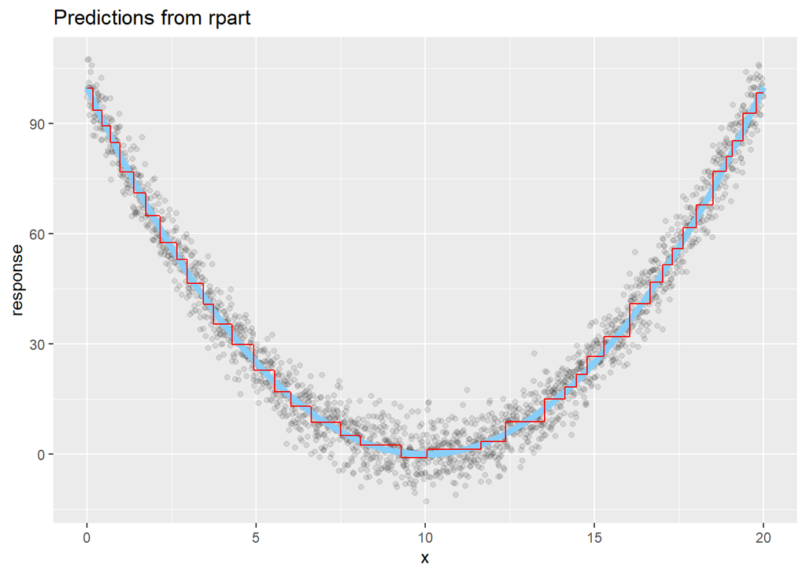

```r
makeLearner("regr.rpart", id = "rpart",
            minsplit = 30, cp = 0.0001) %>%

  try_model(tsk_quadratic)
```

This is better, but we can get too far and overfit:

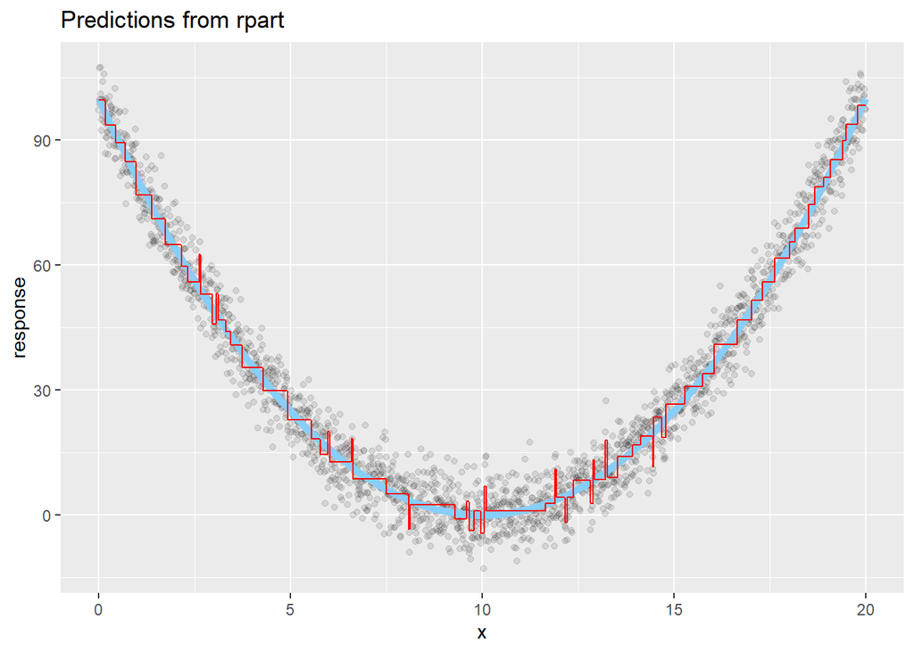

```r
makeLearner("regr.rpart", id = "rpart",
            minsplit = 10, cp = 0.00005) %>%

  try_model(tsk_quadratic)
```

## Conditional Inference Tree (ctree)

The ctree algorithm couldn’t fit the data properly:

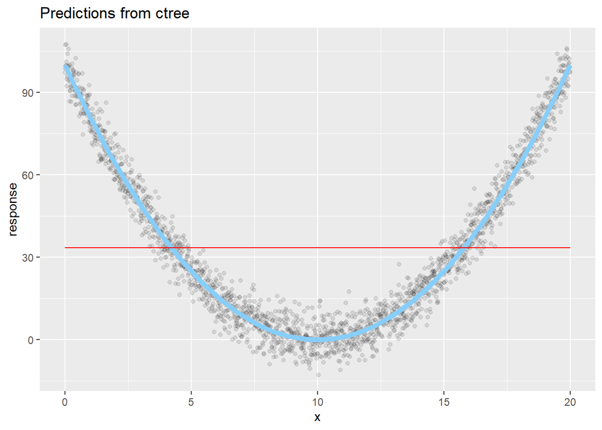

```r
makeLearner("regr.ctree", id = "ctree") %>%
  try_model(tsk_quadratic)
```

Tuning the parameters didn’t help, until the polynomial dataset was provided:

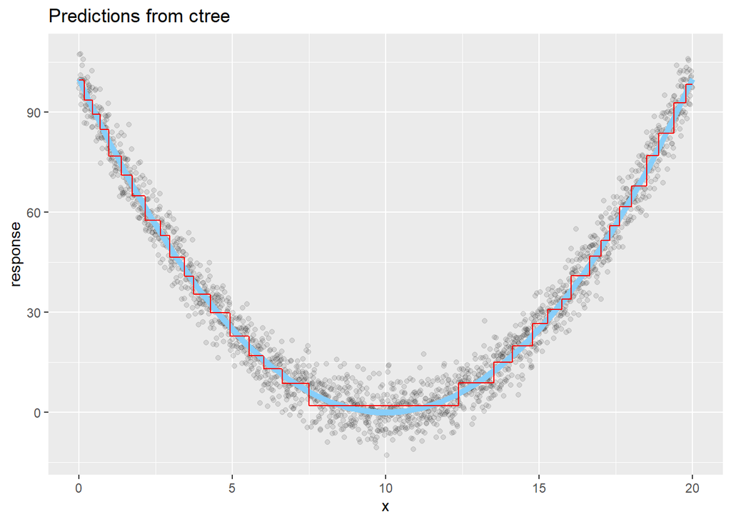

```r
makeLearner("regr.ctree", id = "ctree") %>%
  try_model(tsk_quadratic_poly)
```

# Ensemble models

Let’s try a few ensemble-based models.

## Bagging/Random Forest

The idea behind bagging is replacing a single model with an ensemble of models training on the resampled data. Each model gets a different training dataset, resampled from the initial training data. Predictions are made by averaging the predicted responses from all trees in the ensemble. Such prediction is expected to be more robust compared to a single tree. The random forest further develops this idea by increasing the diversity of trees consisting an ensemble. This is achieved by randomly selecting a subset of predictors before training a new tree. In our example we have just one predictor, so only the bagging approach is feasible. Here we use the randomForest package, that implements both approaches.

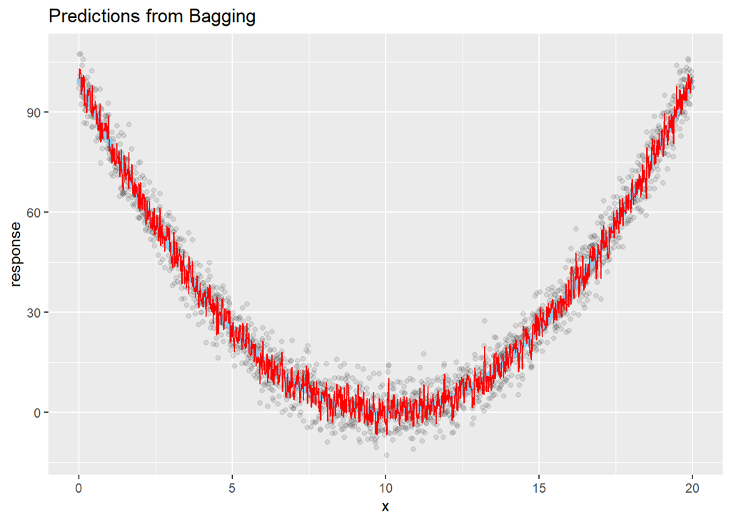

```r
makeLearner("regr.randomForest", id = "Bagging",
             mtry = 1 # the number of predictors to consider for each tree
) %>%
  try_model(tsk_quadratic)
```

The model is overfit.

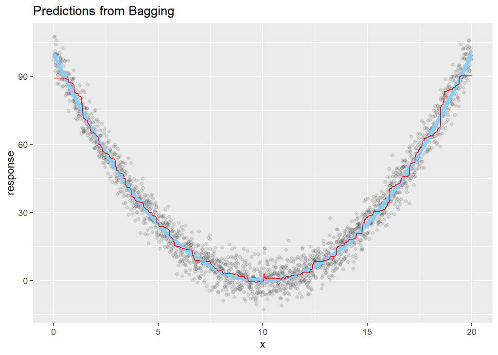

```r
makeLearner("regr.randomForest", id = "Bagging",
            mtry = 1, # the number of predictors to consider for each tree
            nodesize = 150 # minimum node size for a tree
) %>%
  try_model(tsk_quadratic)
```

## Gradient Boosting Machine

Boosting is another ensemble-based approach. In contrast to bagging, the trees are produced sequentially. Each tree is trained on the residuals from the previous tree.

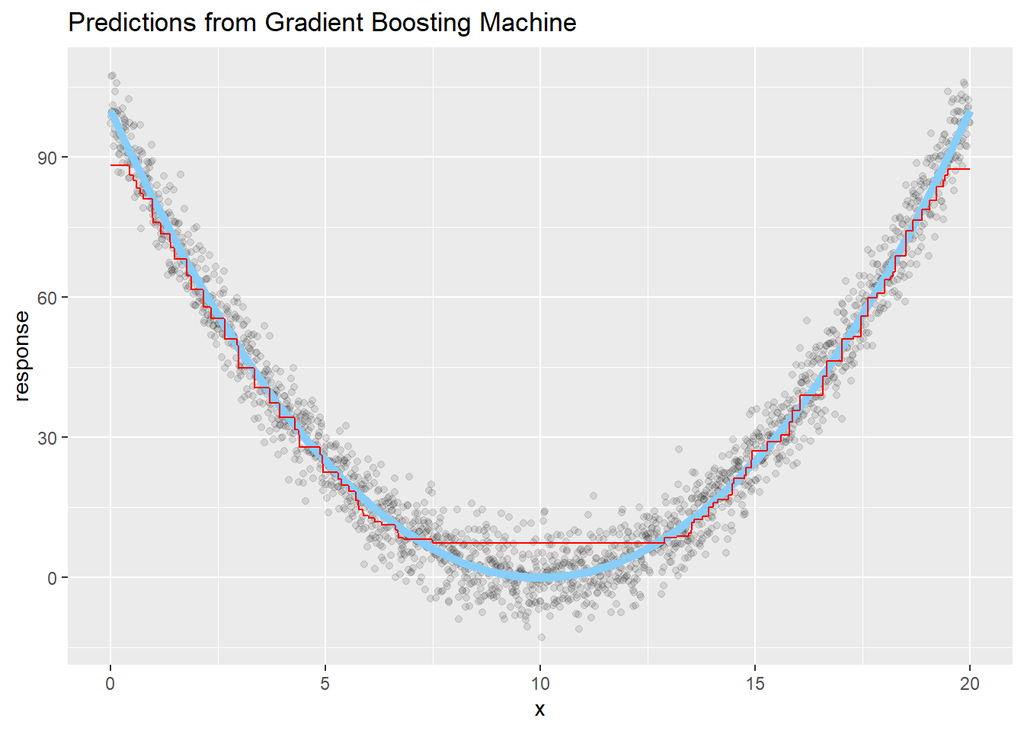

```r
makeLearner("regr.gbm", id = "Gradient Boosting Machine") %>%
  try_model(task = tsk_quadratic)
```

The model fits the data well except around the minimum point of the parabola.

Let’s try adjusting the parameters:

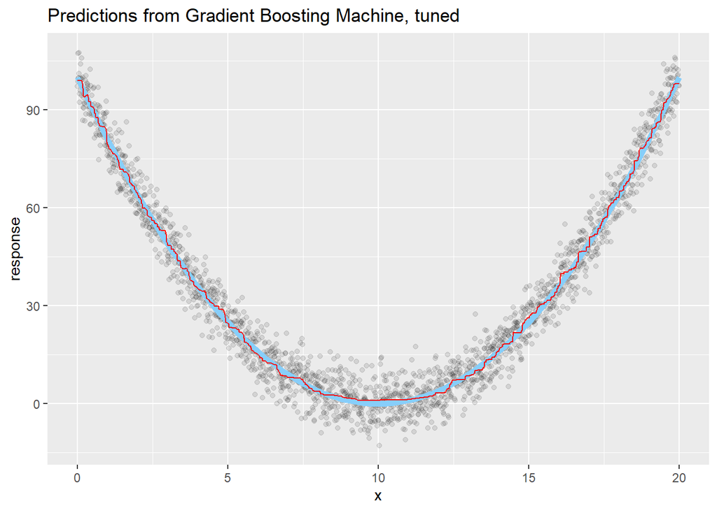

```r
makeLearner("regr.gbm", id = "Gradient Boosting Machine, tuned",
            n.trees = 3500, # Number of trees in the ensemble
            shrinkage = 0.01 # learning rate
) %>%
  try_model(task = tsk_quadratic)
```

```r
makeLearner("regr.gbm") %>%
  getLearnerParamSet()
```

```
##                       Type len      Def
## distribution      discrete   - gaussian
## n.trees            integer   -      100
## cv.folds           integer   -        0
## interaction.depth  integer   -        1
## n.minobsinnode     integer   -       10
## shrinkage          numeric   -    0.001
## bag.fraction       numeric   -      0.5
## train.fraction     numeric   -        1
## alpha              numeric   -      0.5
## keep.data          logical   -     TRUE
## verbose            logical   -    FALSE
##                                                    Constr Req Tunable
## distribution      gaussian,laplace,poisson,tdist,quantile   -    TRUE
## n.trees                                          1 to Inf   -    TRUE
## cv.folds                                      -Inf to Inf   -    TRUE
## interaction.depth                                1 to Inf   -    TRUE
## n.minobsinnode                                   1 to Inf   -    TRUE
## shrinkage                                        0 to Inf   -    TRUE
## bag.fraction                                       0 to 1   -    TRUE
## train.fraction                                     0 to 1   -    TRUE
## alpha                                              0 to 1   Y    TRUE
## keep.data                                               -   -   FALSE
## verbose                                                 -   -   FALSE
##                   Trafo
## distribution          -
## n.trees               -
## cv.folds              -
## interaction.depth     -
## n.minobsinnode        -
## shrinkage             -
## bag.fraction          -
## train.fraction        -
## alpha                 -
## keep.data             -
## verbose               -
```

## XGBoost

Extreme gradient boosting is a popular algorithm also employing the boosting idea. It has built-in regularization to prevent overfitting.

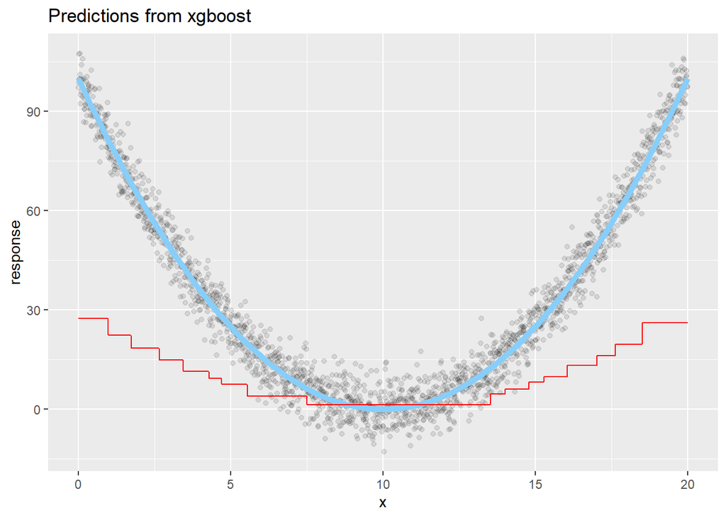

```r
makeLearner("regr.xgboost", id = "xgboost") %>%
  try_model(tsk_quadratic)
```

With default parameters, the algorithm couldn’t fit $f(x)$.

```r
makeLearner("regr.xgboost") %>%
  getLearnerParamSet()
```

```
##                                 Type  len        Def               Constr
## booster                     discrete    -     gbtree gbtree,gblinear,dart
## watchlist                    untyped    -     <NULL>                    -
## eta                          numeric    -        0.3               0 to 1
## gamma                        numeric    -          0             0 to Inf
## max_depth                    integer    -          6             1 to Inf
## min_child_weight             numeric    -          1             0 to Inf
## subsample                    numeric    -          1               0 to 1
## colsample_bytree             numeric    -          1               0 to 1
## colsample_bylevel            numeric    -          1               0 to 1
## num_parallel_tree            integer    -          1             1 to Inf
## lambda                       numeric    -          1             0 to Inf
## lambda_bias                  numeric    -          0             0 to Inf
## alpha                        numeric    -          0             0 to Inf
## objective                    untyped    - reg:linear                    -
## eval_metric                  untyped    -       rmse                    -
## base_score                   numeric    -        0.5          -Inf to Inf
## max_delta_step               numeric    -          0             0 to Inf
## missing                      numeric    -                     -Inf to Inf
## monotone_constraints   integervector <NA>          0              -1 to 1
## tweedie_variance_power       numeric    -        1.5               1 to 2
## nthread                      integer    -          -             1 to Inf
## nrounds                      integer    -          1             1 to Inf
## feval                        untyped    -     <NULL>                    -
## verbose                      integer    -          1               0 to 2
## print_every_n                integer    -          1             1 to Inf
## early_stopping_rounds        integer    -     <NULL>             1 to Inf
## maximize                     logical    -     <NULL>                    -
## sample_type                 discrete    -    uniform     uniform,weighted
## normalize_type              discrete    -       tree          tree,forest
## rate_drop                    numeric    -          0               0 to 1
## skip_drop                    numeric    -          0               0 to 1
## callbacks                    untyped    -                               -
##                        Req Tunable Trafo
## booster                  -    TRUE     -
## watchlist                -   FALSE     -
## eta                      -    TRUE     -
## gamma                    -    TRUE     -
## max_depth                -    TRUE     -
## min_child_weight         -    TRUE     -
```

[output cut: 11 more lines]

```
## missing                  -   FALSE     -
## monotone_constraints     -    TRUE     -
## tweedie_variance_power   Y    TRUE     -
## nthread                  -   FALSE     -
## nrounds                  -    TRUE     -
## feval                    -   FALSE     -
## verbose                  -   FALSE     -
## print_every_n            Y   FALSE     -
## early_stopping_rounds    -   FALSE     -
## maximize                 -   FALSE     -
## sample_type              Y    TRUE     -
## normalize_type           Y    TRUE     -
## rate_drop                Y    TRUE     -
## skip_drop                Y    TRUE     -
## callbacks                -   FALSE     -
```

By adjusting the parameters, we can get better results:

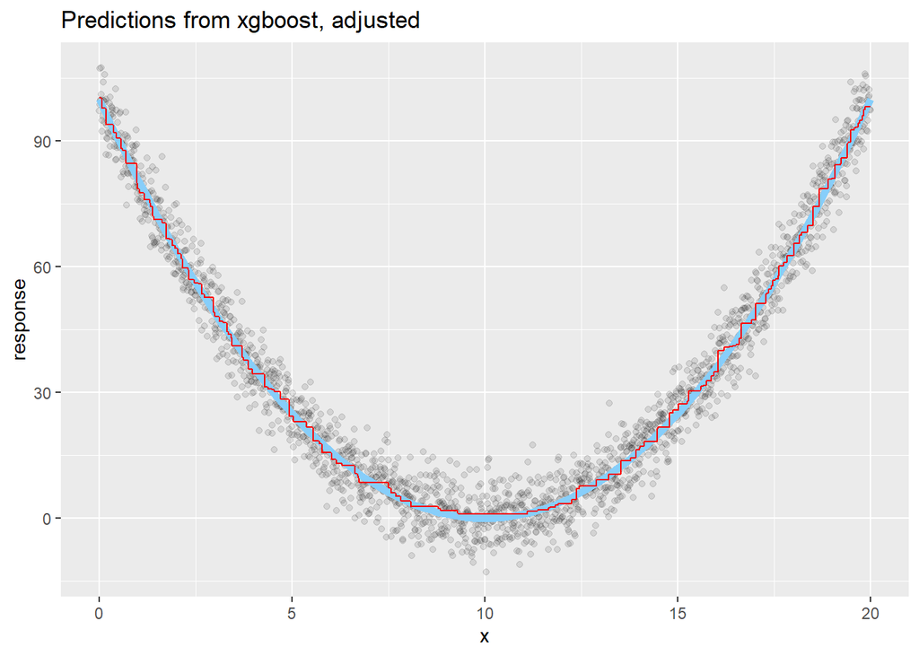

```r
makeLearner("regr.xgboost", id = "xgboost, adjusted",
            eta = 0.02, #learning rate
            nrounds = 2000, # number of trees
            max_depth = 1 # maximum depth of a tree
            ) %>%
  try_model(tsk_quadratic)
```

## Tuning the parameters for xgboost

Setting the parameter search space:

```r
ps_xgb_quadratic <- makeParamSet(
         makeIntegerParam("max_depth",lower = 1L,upper = 6L),
         makeIntegerParam("nrounds",lower = 1L,upper = 4000L),
         makeNumericParam("min_child_weight",lower = 1L,upper = 100L),
         makeNumericParam("subsample",lower = 0.5, upper = 1),
         #makeNumericParam("lambda",lower = -1, upper = 2, trafo = function(x){10^x}),
         makeNumericParam("gamma",lower = -5, upper = 1, trafo = function(x){10^x}),
         makeNumericParam("eta",lower = -3, upper = -1, trafo = function(x){10^x}))
```

Selecting the search algorithm (here we use simulated annealing):

```r
ctrl_quadratic <-
  makeTuneControlGenSA(budget = 50, maxit = 50, max.time = 300)
```

Creating resample description for CV with only 5 folds to speed up search.

```r
rdesc_CV5 <- makeResampleDesc(method = "CV",
                                   iter = 5)
```

Running the search. The results will be cached, to prevent long report knitting time.

```r
# Setting the random number generator for reproducibility
set.seed(123, "L'Ecuyer")

fname <- "xgboost_tune_quadratic.RDS"

if (file.exists(fname)) {
  xgboost_tune_quadratic <- readRDS(fname)
} else {
  parallelStart()

  xgboost_tune_quadratic <-
    tuneParams(
      learner = makeLearner("regr.xgboost"),
      task = tsk_quadratic,
      resampling = rdesc_CV5,
      measures = mape,
      par.set = ps_xgb_quadratic,
      control = ctrl_quadratic,
      show.info = T
    )

  parallelStop()

  saveRDS(xgboost_tune_quadratic, file = fname)
}
```

Optimized parameter values:

```r
xgboost_tune_quadratic$y
```

```
## mape.test.mean
##      0.7905524
```

```r
xgboost_tune_quadratic$x
```

```
## $max_depth
## [1] 5
##
## $nrounds
## [1] 3191
##
## $min_child_weight
## [1] 86.72578
##
## $subsample
## [1] 0.8866039
##
## $gamma
## [1] 0.0886396
##
## $eta
## [1] 0.006234991
```

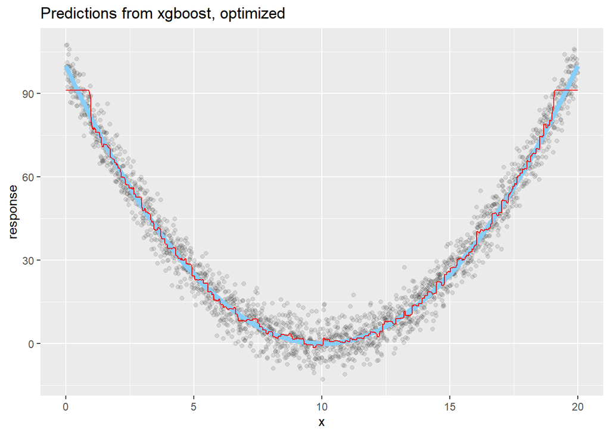

```r
makeLearner("regr.xgboost", id = "xgboost, optimized") %>%
  setHyperPars(par.vals = xgboost_tune_quadratic$x) %>%
  try_model(tsk_quadratic)
```